# Statistics Project 2022 - TED Talks data analysis

## 1. Introduction:

In this project, we will explore a dataset of TED talks from Kaggle using R notebook. TED talks are influential talks given by experts from various fields that cover a wide range of topics such as science, technology, business, entertainment, and more. The dataset contains information about TED talks given from 1/1970 to 2/2022, including 6 different features of each talk available on TED’s website:

- title - Title of the Talk
- author - Author of Talk
- date - Date when the talk took place
- views - Number of views of the Talk
- likes - Number of likes of the Talk
- link - Link of the talk from ted.com

Dataset link: https://www.kaggle.com/datasets/ashishjangra27/ted-talks

Our goal is to analyze the data and gain insights into the trends and patterns of TED talks. We will use various statistical techniques and visualization tools to explore the data and answer questions such as:

- What is the relationship between ‘views’ and ‘quarter’?
- What is the relationship between ‘views’ and ‘like’?
- …

By the end of the project, we hope to have a better understanding of the TED talks data and how statistical analysis can provide valuable insights into real-world data.

## 2. Pre-processing data:

### 2.1 Import and overview data

```r
tedtalks<-read.csv("data.csv")
#Print 6 first line of dataset
head(tedtalks)
```

|  | title | author | date | views | likes | link |
| --- | --- | --- | --- | --- | --- | --- |
| 1 | Climate action needs new frontline leadership | Ozawa Bineshi Albert | December 2021 | 404000 | 12000 | https://ted.com/talks/ozawa_bineshi_albert_climate_action_needs_new_frontline_leadership |
| 2 | The dark history of the overthrow of Hawaii | Sydney Iaukea | February 2022 | 214000 | 6400 | https://ted.com/talks/sydney_iaukea_the_dark_history_of_the_overthrow_of_hawaii |
| 3 | How play can spark new ideas for your business | Martin Reeves | September 2021 | 412000 | 12000 | https://ted.com/talks/martin_reeves_how_play_can_spark_new_ideas_for_your_business |
| 4 | Why is China appointing judges to combat climate change? | James K. Thornton | October 2021 | 427000 | 12000 | https://ted.com/talks/james_k_thornton_why_is_china_appointing_judges_to_combat_climate_change |
| 5 | Cement's carbon problem — and 2 ways to fix it | Mahendra Singhi | October 2021 | 2400 | 72 | https://ted.com/talks/mahendra_singhi_cement_s_carbon_problem_and_2_ways_to_fix_it |
| 6 | The tragedy of air pollution — and an urgent demand for clean air | Rosamund Adoo-Kissi-Debrah | October 2021 | 422000 | 12000 | https://ted.com/talks/rosamund_adoo_kissi_debrah_the_tragedy_of_air_pollution_and_an_urgent_demand_for_clean_air |

```r
#Print columns name of dataset
colnames(tedtalks)
```

```
[1] "title"  "author" "date"   "views"  "likes"  "link"
```

### 2.2 Cleaning data

```r
#Getting info about the missing data
colSums(is.na(tedtalks))
```

```
 title author   date  views  likes   link
     0      0      0      0      0      0
```

There is no NA values, no cleaning needed.

### 2.3 Transform data

To meet our intended plan for later data analysis, we need to do some transformation on the data

```r
#Changing "date" column to "year" column.
tedtalks$month <- substr(tedtalks$date,0, nchar(tedtalks$date)-5)
tedtalks$date = as.numeric(substr(tedtalks$date,nchar(tedtalks$date)-4, nchar(tedtalks$date)))
names(tedtalks)[names(tedtalks) == "date"] <- "year"

#Filtering the data frame to do statistic only in a twenty-year period from 2002 to 2021
tedtalks = subset(tedtalks, year >= 2002 & year <= 2021)

#Add new column "quarter" to the data frame
tedtalks = tedtalks %>%
  mutate(quarter = case_when(
    month == "January" | month == "February" | month == "March"  ~ "Q1",
    month == "April" | month == "May" | month == "June"  ~ "Q2",
    month == "July" | month == "August" | month == "September"  ~ "Q3",
    month == "October" | month == "November" | month == "December"  ~ "Q4"
  ))

head(tedtalks,3)
```

|  | title | author | year | views | likes | link | month | quarter |
| --- | --- | --- | --- | --- | --- | --- | --- | --- |
| 1 | Climate action needs new frontline leadership | Ozawa Bineshi Albert | 2021 | 404000 | 12000 | https://ted.com/talks/ozawa_bineshi_albert_climate_action_needs_new_frontline_leadership | December | Q4 |
| 3 | How play can spark new ideas for your business | Martin Reeves | 2021 | 412000 | 12000 | https://ted.com/talks/martin_reeves_how_play_can_spark_new_ideas_for_your_business | September | Q3 |
| 4 | Why is China appointing judges to combat climate change? | James K. Thornton | 2021 | 427000 | 12000 | https://ted.com/talks/james_k_thornton_why_is_china_appointing_judges_to_combat_climate_change | October | Q4 |

## 3. Some basic statistic:

```r
#Basic statistical info of the dataset.
summary(tedtalks)
```

```
    title              author               year          views              likes             link              month             quarter
 Length:5401        Length:5401        Min.   :2002   Min.   :     532   Min.   :     15   Length:5401        Length:5401        Length:5401
 Class :character   Class :character   1st Qu.:2012   1st Qu.:  678000   1st Qu.:  20000   Class :character   Class :character   Class :character
 Mode  :character   Mode  :character   Median :2016   Median : 1300000   Median :  41000   Mode  :character   Mode  :character   Mode  :character
                                       Mean   :2015   Mean   : 2070074   Mean   :  62868
                                       3rd Qu.:2019   3rd Qu.: 2100000   3rd Qu.:  65000
                                       Max.   :2021   Max.   :72000000   Max.   :2100000
```

```r
#Count unique values in each column
sapply(tedtalks, n_distinct)
```

```
  title  author    year   views   likes    link   month quarter
   5401    4424      20     967     751    5401      12       4
```

## 4. Testing the relationship between ‘views’ and ‘quarter’:

In this section, we will use some tests to verify the difference in Views between quarters

First, we try to use ANOVA. The one-way analysis of variance (ANOVA), also known as one-factor ANOVA, is an extension of independent two-samples t-test for comparing means in a situation where there are more than two groups. In one-way ANOVA, the data is organized into several groups base on one single grouping variable (also called factor variable). In this part, we will use R to do ANOVA test.

### 4.0 Transform data:

To begin, we set the ‘quarter’ field to factor type

```r
#set quarter as factor
tedtalks$quarter = as.factor(tedtalks$quarter)

head(tedtalks,3)
```

|  | title | author | year | views | likes | link | month | quarter |
| --- | --- | --- | --- | --- | --- | --- | --- | --- |
| 1 | Climate action needs new frontline leadership | Ozawa Bineshi Albert | 2021 | 404000 | 12000 | https://ted.com/talks/ozawa_bineshi_albert_climate_action_needs_new_frontline_leadership | December | Q4 |
| 3 | How play can spark new ideas for your business | Martin Reeves | 2021 | 412000 | 12000 | https://ted.com/talks/martin_reeves_how_play_can_spark_new_ideas_for_your_business | September | Q3 |
| 4 | Why is China appointing judges to combat climate change? | James K. Thornton | 2021 | 427000 | 12000 | https://ted.com/talks/james_k_thornton_why_is_china_appointing_judges_to_combat_climate_change | October | Q4 |

```r
levels(tedtalks$quarter)
```

```
[1] "Q1" "Q2" "Q3" "Q4"
```

### 4.1 Descriptive statistics and graph

```r
# We will find out count, mean, standard deviation of each quarter.
group_by(tedtalks, quarter) %>%
  summarise(
    count = n(),
    mean = mean(views, na.rm = TRUE),
    sd = sd(views, na.rm = TRUE)
  )
```

| quarter | count | mean | sd |
| --- | --- | --- | --- |
| Q1 | 1417 | 2562470 | 4283544 |
| Q2 | 1389 | 2185096 | 3848073 |
| Q3 | 994 | 1776917 | 2942252 |
| Q4 | 1601 | 1716489 | 2884747 |

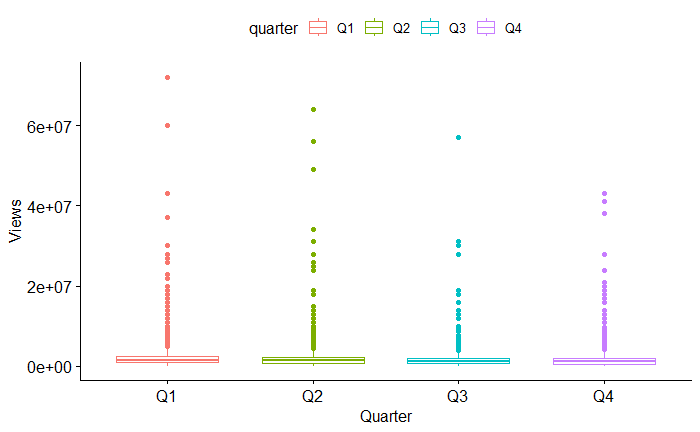

```r
# Plot box graph for quarter and views.
ggboxplot(tedtalks, x = "quarter", y = "views",
          color = "quarter",
          order = c("Q1", "Q2", "Q3", "Q4"),
          ylab = "Views", xlab = "Quarter")
```

From the box plot, we can see that there are some outliers in the data frame. To do the ANOVA test, we need to check the homogeneity of variance with outliers. For this activity, we use Levene Test and start checking with the data frame that has outliers.

```r
# Check the homogeneity of variance with outliers
leveneTest(views ~ quarter, data = tedtalks)
```

```
Levene's Test for Homogeneity of Variance (center = median)
        Df F value    Pr(>F)
group    3  7.9001 2.955e-05 ***
      5397
---
Signif. codes:  0 ‘***’ 0.001 ‘**’ 0.01 ‘*’ 0.05 ‘.’ 0.1 ‘ ’ 1
```

We can see that the p-value is less than the significance level of 0.05. This means we can not assume the homogeneity of variances in the different quarters. Since the variance across quarters are non-homogeneous with outliers in the data set, we will remove outliers and check again. We check number of rows in the data frame before removing outliers.

```r
dim(tedtalks) #Check data frame before removing outliers
```

```
[1] 5401    8
```

```r
#Removing outlier using Interquartile range method:
quartiles <- quantile(tedtalks$views, probs=c(.25, .75), na.rm = FALSE)
IQR <- IQR(tedtalks$views)

Lower <- quartiles[1] - 1.5*IQR
Upper <- quartiles[2] + 1.5*IQR

tedtalks_no_outlier <- subset(tedtalks, tedtalks$views > Lower & tedtalks$views < Upper)

dim(tedtalks_no_outlier) #Check data frame after removing outliers
```

```
[1] 4898    8
```

We can see that after remove outliers, there are only 4898 rows left. Now we use Levene Test to check the homogeneity of variance without outliers.

```r
leveneTest(views ~ quarter, data = tedtalks_no_outlier)
```

```
Levene's Test for Homogeneity of Variance (center = median)
        Df F value Pr(>F)
group    3  1.2473 0.2908
      4894
```

From the output above we can see that the p-value is not less than the significance level of 0.05. This means that there is no evidence to suggest that the variance across groups is statistically significantly different. Therefore, we can assume the homogeneity of variance in the different quarters.

Let’s draw a the box plot with the mean value for views in each quarter and a line plot with the mean standard error for views in each quarter after removing outliers.

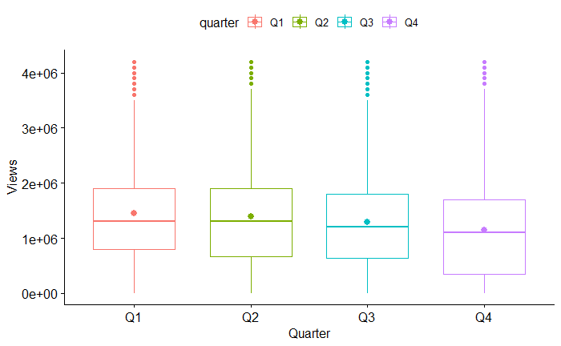

```r
# Box plot for quarter and views after removing outlier
ggboxplot(tedtalks_no_outlier, x = "quarter", y = "views",
          add = c("mean"),
          color = "quarter",
          order = c("Q1", "Q2", "Q3", "Q4"),
          ylab = "Views", xlab = "Quarter")
```

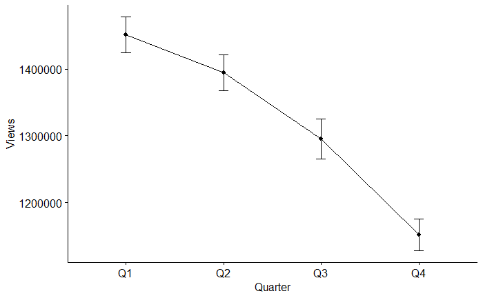

```r
# Line plot with the mean standard error for views in each quarter after removing outliers
ggline(tedtalks_no_outlier, x = "quarter", y = "views",
       add = c("mean_se"),
       order = c("Q1", "Q2", "Q3", "Q4"),
       ylab = "Views", xlab = "Quarter")
```

Pre-check normality or the data frame corresponding to each quarter.

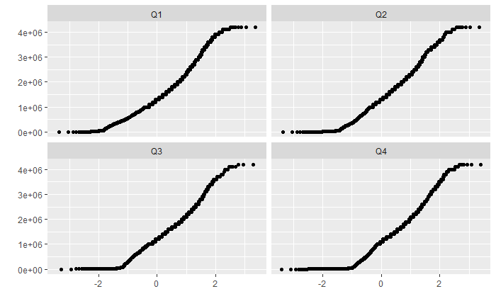

```r
qplot(sample = views, data = tedtalks_no_outlier, facets = ~ quarter)
```

### 4.2 ANOVA test

```r
# Compute the analysis of variance
res.aov <- aov(views ~ quarter, data = tedtalks_no_outlier)
# Summary of the analysis
summary(res.aov)
```

```
              Df    Sum Sq   Mean Sq F value Pr(>F)
quarter        3 7.127e+13 2.376e+13   27.38 <2e-16 ***
Residuals   4894 4.247e+15 8.678e+11
---
Signif. codes:  0 ‘***’ 0.001 ‘**’ 0.01 ‘*’ 0.05 ‘.’ 0.1 ‘ ’ 1
```

The output includes the columns F value and Pr(>F) corresponding to the p-value of the test. As the p-value is less than the significance level 0.05, we can conclude that there are significant differences between the quarters.

Now, we use Tukey multiple pairwise-comparisons to check whether the mean difference between specific pairs of quarter are statistically significant.

```r
# Compute Tukey HSD (Tukey Honest Significant Differences, R function: TukeyHSD())

# For performing multiple pairwise-comparison between the means of groups
TukeyHSD(res.aov)
```

```
  Tukey multiple comparisons of means
    95% family-wise confidence level

Fit: aov(formula = views ~ quarter, data = tedtalks_no_outlier)

$quarter
            diff       lwr         upr     p adj
Q2-Q1  -56635.79 -152787.7   39516.098 0.4292435
Q3-Q1 -156470.21 -260587.8  -52352.644 0.0006579
Q4-Q1 -300512.17 -392817.1 -208207.207 0.0000000
Q3-Q2  -99834.43 -203485.5    3816.639 0.0639368
Q4-Q2 -243876.38 -335654.8 -152097.948 0.0000000
Q4-Q3 -144041.95 -244134.7  -43949.177 0.0012550
```

From the output, we can see that only the difference between Q3 and Q1, Q4 and Q1, Q4 and Q2, Q4 and Q3 is significant with an adjusted p-value less than 0.05.

Now we need to check the ANOVA assumption. The ANOVA test assumes that, the data are normally distributed and the variance across quarters are homogeneous. We can check that with some diagnostic plots. We have already checked the homogeneity of variance. Therefore, we only need to check the normality of the test.

First, we use Q-Q plot.

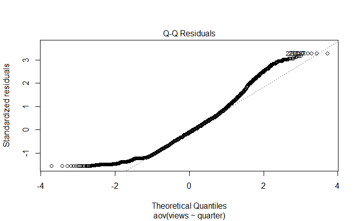

```r
# Check the normality assumption
plot(res.aov, 2)
```

```r
#Using Shapiro-Wilk test on the ANOVA residuals
# Extract the residuals
aov_residuals <- residuals(object = res.aov )
# Run Shapiro-Wilk test
shapiro.test(x = aov_residuals)
```

```
    Shapiro-Wilk normality test

data:  aov_residuals
W = 0.95328, p-value < 2.2e-16
```

The p-value is less than 0.05, so we can not assume the normality of the test. Hence, we can not use ANOVA to test the relationship between views and quarters.

Instead, we will use another test named Kruskal-Wallis rank sum test, which is a non-parametric alternative to one-way ANOVA.

## 4.3 Kruskal-Wallis rank sum test

```r
#ANOVA assumptions are not met, alternatively using Kruskal-Wallis rank sum test
kruskal.test(views ~ quarter, data = tedtalks_no_outlier)
```

```
    Kruskal-Wallis rank sum test

data:  views by quarter
Kruskal-Wallis chi-squared = 86.412, df = 3, p-value < 2.2e-16
```

The p-value is less than 0.05 so we can conclude that there are significant differences between the quarters.

Now, we use Multiple pairwise-comparison to check whether the mean difference between specific pairs of quarter are statistically significant.

```r
#Calculate pairwise comparisons between group levels with corrections for multiple testing
pairwise.wilcox.test(tedtalks_no_outlier$views, tedtalks_no_outlier$quarter,
                     p.adjust.method = "BH")
```

```
    Pairwise comparisons using Wilcoxon rank sum test with continuity correction

data:  tedtalks_no_outlier$views and tedtalks_no_outlier$quarter

   Q1      Q2      Q3
Q2 0.21058 -       -
Q3 0.00065 0.01705 -
Q4 < 2e-16 2.5e-12 7.8e-05

P value adjustment method: BH
```

From the output, the difference between Q3 and Q1, Q3 and Q2, Q4 and Q1, Q4 and Q2, Q4 and Q3 are significant with an adjusted p-value less than 0.05.

> Conclusion: There are significant differences in views between the quarters

## 5. Linear regression models to quantify the strength of the relationship between likes and views:

Linear regression is basically the procedure to fit a straight line to the data. What this line does is either predicting the value of the response variable based on the value of explanatory or predictor variables or quantifying the strength of the relationship between the response and the explanatory variables. In this section, we use simple linear regression models to quantify the strength of the relationship between likes and views and try to predict views based on likes.

First, we pre-check the linear relationship between views and likes.

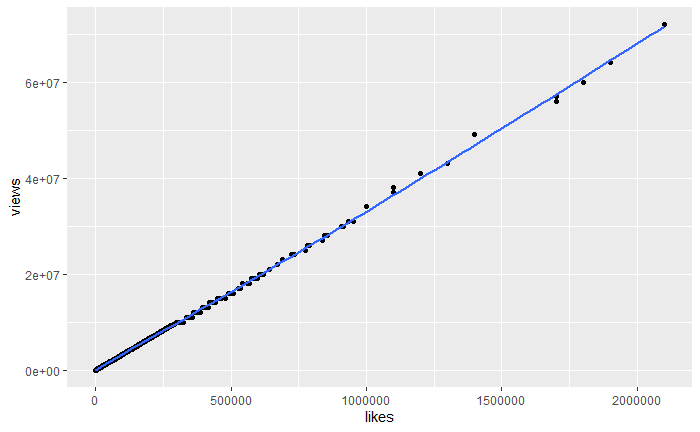

```r
#Linear relationship between views and likes
ggplot(tedtalks, aes(x = likes, y = views)) +
  geom_point() +
  stat_smooth()
```

From the plot, we can assume that likes and views have linear relationship. Hence, we can start to build the model now and check all assumptions later.

### 5.1 Building the model

To begin, we randomly split the data into training set (80% for training a predictive model) and testing set (20% for evaluating the model).

```r
#Split the data set into train set and test set
set.seed(123)
training.samples <- tedtalks$views %>%
  createDataPartition(p = 0.8, list = FALSE)
train.data  <- tedtalks[training.samples, ]
test.data <- tedtalks[-training.samples, ]
```

Then, we start to compute our simple linear regression model by using lm() function on the train data set.

```r
#Build the model
model <- lm(views ~ likes, data = train.data)
summary(model)
```

```
Call:
lm(formula = views ~ likes, data = train.data)

Residuals:
    Min      1Q  Median      3Q     Max
-849767  -12609   12982   24449 2472023

Coefficients:
              Estimate Std. Error  t value Pr(>|t|)
(Intercept) -1.196e+04  1.587e+03   -7.537 5.83e-14 ***
likes        3.311e+01  1.226e-02 2702.092  < 2e-16 ***
---
Signif. codes:  0 ‘***’ 0.001 ‘**’ 0.01 ‘*’ 0.05 ‘.’ 0.1 ‘ ’ 1

Residual standard error: 90840 on 4321 degrees of freedom
Multiple R-squared:  0.9994,    Adjusted R-squared:  0.9994
F-statistic: 7.301e+06 on 1 and 4321 DF,  p-value: < 2.2e-16
```

The output above shows the estimate of the regression beta coefficients (column Estimate) and their significance levels (column Pr(>|t|). The intercept (b0) is -11960 and the coefficient of likes variable is 33.11.

The estimated regression equation can be written as follow: views = -11960 + 33.11*likes. Using this formula, we believe that if we convey a survey to collect reaction about a topic, we could estimate the number of views in a set of people that know the existence of a ted talk show.

### 5.2 Evaluate the model

We check how well the model fits the data (goodness-of-fit) using the following three quantities, displayed in the model summary:

- Residual Standard Error (RSE),
- R-squared (R2) and adjusted R2,
- F-statistic, which has been already described in the previous section.

#### 5.2.1 Residual standard error (RSE)

The RSE (or model sigma), corresponding to the prediction error, represents roughly the average difference between the observed outcome values and the predicted values by the model.The lower the RSE the best the model fits to our data.

Dividing the RSE by the average value of the outcome variable will give you the prediction error rate, which should be as small as possible.

```r
#Calculate mean of views in train data set to calculate error rate
mean(train.data$views)
```

```
[1] 2098262
```

In our example, using only likes predictor variables, the RSE = 90840, meaning that the observed views values deviate from the predicted values by approximately 90840 units in average.

This corresponds to an error rate of 90840/mean(train.data$views) = 90840/2098262 = 4.33%, which is low.

```r
error_rate = 90840/2098262
error_rate
```

```
[1] 0.04329297
```

#### 5.2.2 R-squared and Adjusted R-squared

The R-squared (R2) ranges from 0 to 1 and represents the proportion of variation in the outcome variable that can be explained by the model predictor variables.

For a simple linear regression, R2 is the square of the Pearson correlation coefficient between the outcome and the predictor variables.

The R2 measures, how well the model fits the data. The higher the R2, the better the model. However, a problem with the R2, is that, it will always increase when more variables are added to the model, even if those variables are only weakly associated with the outcome (James et al. 2014). A solution is to adjust the R2 by taking into account the number of predictor variables.

The adjustment in the “Adjusted R Square” value in the summary output is a correction for the number of x variables included in the predictive model.

So, we mainly consider the adjusted R-squared, which is a penalized R2 for a higher number of predictors.

In our example, the adjusted R2 is 0.9994, which is good.

#### 5.2.3 F-Statistic

Recall that, the F-statistic gives the overall significance of the model. It assess whether at least one predictor variable has a non-zero coefficient.

In a simple linear regression, this test is not really interesting since it just duplicates the information given by the t-test, available in the coefficient table.

> From the result of goodness-of-fit, we can conclude that likes are significantly associated to views.

However, we still need to check model assumptions to make sure that our model can be used for prediction.

#### 5.2.4 Check model assumptions

We use plot(model) to draw 4 diagnostic plots of the model and display all of it as a matrix 2x2 on the screen.

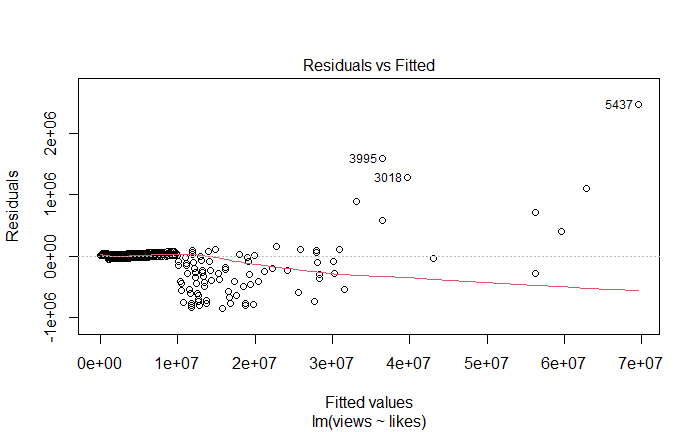

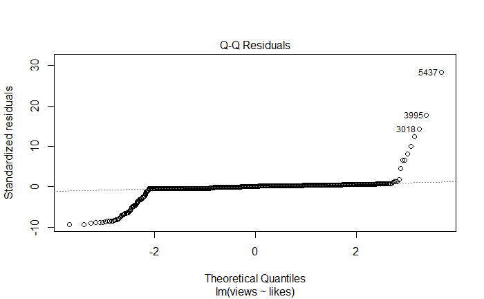

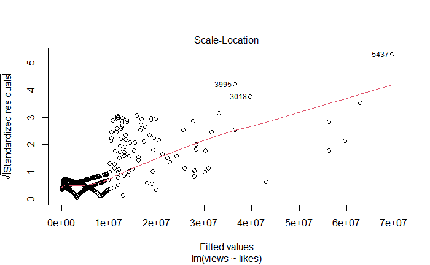

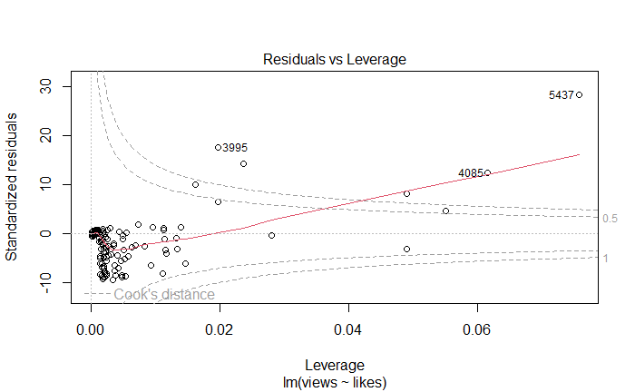

```r
plot(model)
```

The diagnostic plots show residuals in four different ways:

- Residuals vs Fitted: Used to check the linear relationship assumptions. A horizontal line, without distinct patterns is an indication for a linear relationship, is good.
- Normal Q-Q: Used to examine whether the residuals are normally distributed. It’s good if residuals points follow the straight dashed line.
- Scale-Location (or Spread-Location): Used to check the homogeneity of variance of the residuals (homoscedasticity). Horizontal line with equally spread points is a good indication of homoscedasticity.
- Residuals vs Leverage: Used to identify influential cases, that is extreme values that might influence the regression results when included or excluded from the analysis.

##### Linearity of the data:

The linearity assumption can be checked by inspecting the Residuals vs Fitted plot (1st plot).

Ideally, the residual plot will show no fitted pattern. That is, the red line should be approximately horizontal at zero. The presence of a pattern may indicate a problem with some aspect of the linear model.

In our model, at first, red line is approximately horizontal at zero, which is a very good sign. However, it is slightly far from zero at the end, which may be a sign for some problem with our linear model. To verify this, we need further analysis, but for now, we can temporarily assume linear relationship between the predictors and the outcome variables.

##### Homogeneity of variance:

This assumption can be checked by examining the scale-location plot, also known as the spread-location plot.

This plot shows if residuals are spread equally along the ranges of predictors. It’s good if you see a horizontal line with equally spread points. In our example, this is not the case.

It can be seen that the variability (variances) of the residual points increases with the value of the fitted outcome variable, suggesting non-constant variances in the residuals errors (or heteroscedasticity).

A possible solution to reduce the heteroscedasticity problem is to use a log transformation.

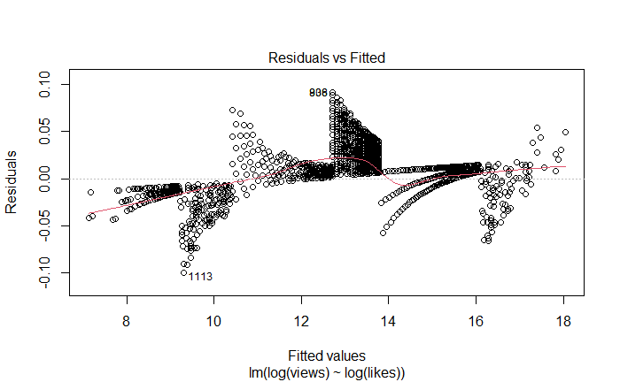

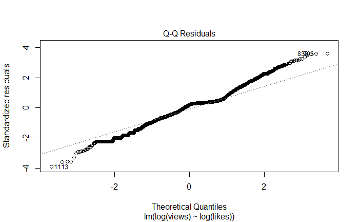

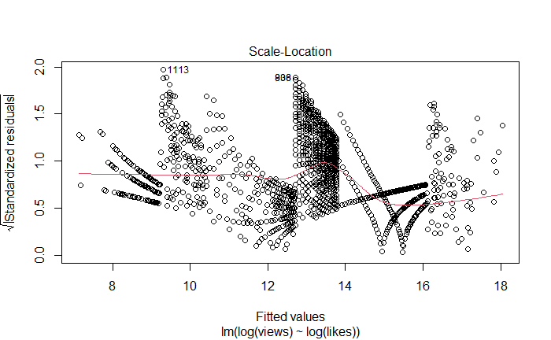

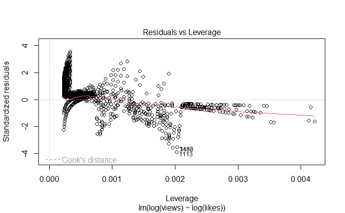

```r
trans_model <- lm(log(views) ~ log(likes), data = train.data)
plot(trans_model)
```

If you look at the Residuals vs Fitted plot again, after apply log transforming, the result become worse and we can hardly say it is linear anymore.

##### Normality of residuals

The Q-Q plot of residuals can be used to visually check the normality assumption. The normal probability plot of residuals should approximately follow a straight line.

##### Outliers and high levarage points:

- Outliers:
  - An outlier is a point that has an extreme outcome variable value. The presence of outliers may affect the interpretation of the model, because it increases the RSE.
  - Outliers can be identified by examining the standardized residual (or studentized residual), which is the residual divided by its estimated standard error. Standardized residuals can be interpreted as the number of standard errors away from the regression line.
  - Observations whose standardized residuals are greater than 3 in absolute value are possible outliers (James et al. 2014).
- High leverage points:
  - A data point has high leverage, if it has extreme predictor x values. This can be detected by examining the leverage statistic or the hat-value. A value of this statistic above 2(p + 1)/n indicates an observation with high leverage (P. Bruce and Bruce 2017); where, p is the number of predictors and n is the number of observations.

Outliers and high leverage points can be identified by inspecting the Residuals vs Leverage plot.

For the model before log transforming, the plot shows many extreme points with a standardized residuals is very high and exceed the Cook’s distance, which is not a very good result.

For the model after log transforming, the plot highlights the top 3 most extreme points with a standardized residuals below -2. However, there is no outliers that exceed Cook’s distance, which is acceptable since there is no high leverage point in the data.

> Overall, the model after do log transforming seems to have a better result. Hence, we will continue using with this model.

##### Model summary and prediction after log transforming:

Since we have re-conduct the model using log transformation, we need to look at model summary again, do goodness-of-fit and measure the prediction performance with the test data set.

```r
summary(trans_model)
```

```
Call:
lm(formula = log(views) ~ log(likes), data = train.data)

Residuals:
      Min        1Q    Median        3Q       Max
-0.099676 -0.015294  0.004564  0.010813  0.091566

Coefficients:
            Estimate Std. Error t value Pr(>|t|)
(Intercept) 3.532559   0.002524    1400   <2e-16 ***
log(likes)  0.996791   0.000243    4102   <2e-16 ***
---
Signif. codes:  0 ‘***’ 0.001 ‘**’ 0.01 ‘*’ 0.05 ‘.’ 0.1 ‘ ’ 1

Residual standard error: 0.0256 on 4321 degrees of freedom
Multiple R-squared:  0.9997,    Adjusted R-squared:  0.9997
F-statistic: 1.683e+07 on 1 and 4321 DF,  p-value: < 2.2e-16
```

```r
mean(log(train.data$views))
```

```
[1] 13.75974
```

```r
error_rate = 0.0256/13.75974
error_rate
```

```
[1] 0.0018605
```

From the summary, we can see that RSE = 0.0256, corresponding to an error rate of 0.0256/13.75974 = 0.186%, the adjusted R2 is 0.9997. This is a very good result.

Now, we do a log transformation with test data set, then make prediction with it and measure the model performance.

```r
# transform test data
test.data$likes = log(test.data$likes)
test.data$views = log(test.data$views)
# make prediction
predictions <- model %>% predict(test.data)
# model performance
# (a) Prediction error, RMSE
RMSE(predictions, test.data$views)
```

```
[1] 11636.65
```

```r
# (b) R-square
R2(predictions, test.data$views)
```

```
[1] 0.99974
```

```r
# calculate mean of views in test data set to calculate error rate
mean(test.data$views)
```

```
[1] 13.73297
```

Therefore, although the model looks good, it does not have a very good prediction performance in test data set.

Hence, we may have failed to conduct an effective prediction model for views based on likes. However, through the model, we could see the relationship between likes and views in ted talks show.

## 6. Conclusion:

After finishing analyzing the data, we has concluded that statistics help in breaking out a problem to find a solution. In our activity, we have been able to import, clean, transform the data, plot the graph for prediction in R.

More specific, we have used ANOVA and Kruskal-Wallis rank sum test to test the dependency of quarters and views, as well as we have conducted a simple linear regression to analyse the relationship between likes and views and tried to build a predictive model of views based on likes.

Although, we have failed to make prediction, however, this is a great experience on building linear regression model and it help us to understand more clearly about how to conduct these tests and model in R language.